# NLA-GP: Empirical Test

- Show All Code
- Hide All Code
- View Source

Author

Leonardo Capitani (leocapi07@gmail.com)

Published

July 19, 2026

Modified

July 20, 2026

```r
library(GPEDM)
library(tidyverse)
library(here)
library(zoo)
```

**Important**

This notebook applies **NLA-GP** to real data: Lake Zurich plankton (Medeiros et al. 2025) and the Pacific Decadal Oscillation index (Huang et al. 2024, Sec. 3.2). See `1_implement.qmd` for the algorithm, its derivation, and validation on synthetic systems with a known regime shift. The NLA-GP (and NLA-S-map) implementation is reproduced below so this notebook runs standalone.

## Code

```r
#' Gaussian-kernel smoothing of an error curve (the paper's "Gaussian filter").
smooth_gaussian <- function(idx, y, bandwidth) {
  keep <- is.finite(y)
  if (sum(keep) < 3) return(rep(NA_real_, length(y)))
  out <- rep(NA_real_, length(y))
  xi <- idx[keep]; yi <- y[keep]
  for (i in seq_along(idx)) {
    w <- exp(-0.5 * ((xi - idx[i]) / bandwidth)^2)
    out[i] <- sum(w * yi) / sum(w)
  }
  out
}

#' Is a (smoothed) error curve valley-shaped, and if so, where is the minimum?
#' Discriminant (Huang et al. 2024, Sec 2.2): sign of the first difference is
#' a single run of "-" followed by a single run of "+".
find_valley <- function(idx, y_smooth, flat_tol = 1e-8) {
  ok <- is.finite(y_smooth)
  if (sum(ok) < 3) return(list(is_valley = FALSE, tau_hat = NA_real_))
  idx <- idx[ok]; y_smooth <- y_smooth[ok]
  o <- order(idx); idx <- idx[o]; y_smooth <- y_smooth[o]

  d <- diff(y_smooth)
  scale_ <- max(abs(y_smooth), flat_tol)
  s <- ifelse(abs(d) < flat_tol * scale_, 0, sign(d))
  s_nz <- s[s != 0]
  if (length(s_nz) < 2) return(list(is_valley = FALSE, tau_hat = NA_real_))

  runs <- rle(s_nz)$values
  is_valley <- length(runs) == 2 && identical(runs, c(-1, 1))

  imin <- which.min(y_smooth)
  at_boundary <- imin == 1 || imin == length(y_smooth)
  is_valley <- is_valley && !at_boundary

  list(is_valley = is_valley, tau_hat = if (is_valley) idx[imin] else NA_real_)
}

#' Build lag/predictor columns ONCE over the full series, and z-score them
#' ONCE using a fixed reference (see 1_implement.qmd for why).
build_lag_frame <- function(y, E, tau) {
  T <- length(y)
  base <- data.frame(time = seq_len(T), y = y)
  lagdf <- makelags(data = base, y = "y", E = E, tau = tau, append = TRUE)
  xnames <- setdiff(names(lagdf), c("time", "y"))

  complete <- stats::complete.cases(lagdf[, c("y", xnames)])
  ymean <- mean(lagdf$y[complete]); ysd <- sd(lagdf$y[complete])
  lagdf$y <- (lagdf$y - ymean) / ysd
  for (xn in xnames) {
    xmean <- mean(lagdf[[xn]][complete]); xsd <- sd(lagdf[[xn]][complete])
    lagdf[[xn]] <- (lagdf[[xn]] - xmean) / xsd
  }
  list(lagdf = lagdf, xnames = xnames)
}

fit_hyperparams <- function(lagdf, xnames, lib_start, lib_end, test_rows) {
  train <- lagdf[lagdf$time >= lib_start & lagdf$time <= lib_end, ]
  tryCatch(
    fitGP(data = train, y = "y", x = xnames, scaling = "none", newdata = test_rows),
    error = function(e) NULL
  )
}

refit_fixed <- function(lagdf, xnames, lib_start, lib_end, test_rows, fixedpars) {
  train <- lagdf[lagdf$time >= lib_start & lagdf$time <= lib_end, ]
  if (nrow(na.omit(train[, c("y", xnames)])) < length(xnames) + 2) return(NA_real_)
  fit <- tryCatch(
    fitGP(data = train, y = "y", x = xnames, scaling = "none",
          fixedpars = fixedpars, newdata = test_rows),
    error = function(e) NULL
  )
  if (is.null(fit)) return(NA_real_)
  unname(fit$outsampfitstats["rmse"])
}

#' Left check (Algorithm 1): library = y[1:L], test = y[(L+1):R].
nla_left <- function(y, L, R = length(y), E = 3, tau = 1, Dskipstep = 5,
                      bandwidth = 2 * Dskipstep, min_lib = E * tau + 3) {
  lf <- build_lag_frame(y, E, tau)
  lagdf <- lf$lagdf; xnames <- lf$xnames
  test_rows <- lagdf[lagdf$time >= (L + 1) & lagdf$time <= R, ]

  n_seq <- seq(0, L - min_lib, by = Dskipstep)
  tau_n <- rep(NA_real_, length(n_seq))
  curves <- vector("list", length(n_seq))

  for (i in seq_along(n_seq)) {
    n <- n_seq[i]
    lib_start_n <- max(1, n)
    hp <- fit_hyperparams(lagdf, xnames, lib_start_n, L, test_rows)
    if (is.null(hp)) next
    fixedpars <- hp$pars[seq_len(length(xnames) + 2)]

    l_seq <- seq(n, L - min_lib, by = Dskipstep)
    if (length(l_seq) < 3) next
    err <- vapply(l_seq, function(l) {
      refit_fixed(lagdf, xnames, max(1, l), L, test_rows, fixedpars)
    }, numeric(1))

    y_smooth <- smooth_gaussian(l_seq, err, bandwidth)
    v <- find_valley(l_seq, y_smooth)
    tau_n[i] <- v$tau_hat
    curves[[i]] <- data.frame(n = n, l = l_seq, rmse = err, rmse_smooth = y_smooth)
  }

  list(tau_hat = if (all(is.na(tau_n))) NA_real_ else median(tau_n, na.rm = TRUE),
       tau_n = data.frame(n = n_seq, tau_hat = tau_n),
       curves = do.call(rbind, curves))
}

#' Right check (Algorithm 2): test = y[1:L], library = y[(L+1):R].
nla_right <- function(y, L, R = length(y), E = 3, tau = 1, Dskipstep = 5,
                       bandwidth = 2 * Dskipstep, min_lib = E * tau + 3) {
  lf <- build_lag_frame(y, E, tau)
  lagdf <- lf$lagdf; xnames <- lf$xnames
  test_rows <- lagdf[lagdf$time >= 1 & lagdf$time <= L, ]

  n_seq <- seq(R, L + 1 + min_lib, by = -Dskipstep)
  tau_n <- rep(NA_real_, length(n_seq))
  curves <- vector("list", length(n_seq))

  for (i in seq_along(n_seq)) {
    n <- n_seq[i]
    hp <- fit_hyperparams(lagdf, xnames, L + 1, n, test_rows)
    if (is.null(hp)) next
    fixedpars <- hp$pars[seq_len(length(xnames) + 2)]

    l_seq <- seq(n, L + 1 + min_lib, by = -Dskipstep)
    if (length(l_seq) < 3) next
    err <- vapply(l_seq, function(l) {
      refit_fixed(lagdf, xnames, L + 1, l, test_rows, fixedpars)
    }, numeric(1))

    y_smooth <- smooth_gaussian(l_seq, err, bandwidth)
    v <- find_valley(l_seq, y_smooth)
    tau_n[i] <- v$tau_hat
    curves[[i]] <- data.frame(n = n, l = l_seq, rmse = err, rmse_smooth = y_smooth)
  }

  list(tau_hat = if (all(is.na(tau_n))) NA_real_ else median(tau_n, na.rm = TRUE),
       tau_n = data.frame(n = n_seq, tau_hat = tau_n),
       curves = do.call(rbind, curves))
}
```

The original NLA-S-map (Huang et al. 2024’s S2 Text) is reproduced too, so we can compare it against NLA-GP on the PDO test below, as we did on synthetic data in `1_implement.qmd`.

```r
smap_predict <- function(train_x, train_y, test_x, theta, k = NULL) {
  E <- ncol(train_x)
  if (is.null(k)) k <- E + 1
  N <- nrow(train_x)
  Xtrain1 <- cbind(1, train_x)
  preds <- numeric(nrow(test_x))
  for (i in seq_len(nrow(test_x))) {
    xq <- test_x[i, ]
    d <- sqrt(rowSums((train_x - matrix(xq, N, E, byrow = TRUE))^2))
    dbar <- mean(sort(d)[seq_len(min(k, N))])
    if (dbar <= 0) dbar <- 1e-8
    w <- exp(-theta * d / dbar)
    fit <- tryCatch(lm.wfit(x = Xtrain1, y = train_y, w = w), error = function(e) NULL)
    preds[i] <- if (is.null(fit) || any(!is.finite(fit$coefficients))) NA_real_ else sum(c(1, xq) * fit$coefficients)
  }
  preds
}

fit_smap_theta <- function(train_x, train_y, test_x, test_y) {
  obj <- function(theta) sqrt(mean((test_y - smap_predict(train_x, train_y, test_x, theta))^2, na.rm = TRUE))
  optimize(obj, interval = c(1e-4, 10))$minimum
}

fit_hyperparams_smap <- function(lagdf, xnames, lib_start, lib_end, test_rows) {
  train <- na.omit(lagdf[lagdf$time >= lib_start & lagdf$time <= lib_end, c("y", xnames)])
  test <- na.omit(test_rows[, c("y", xnames)])
  if (nrow(train) < length(xnames) + 2 || nrow(test) == 0) return(NULL)
  list(theta = fit_smap_theta(as.matrix(train[, xnames]), train$y, as.matrix(test[, xnames]), test$y))
}

refit_fixed_smap <- function(lagdf, xnames, lib_start, lib_end, test_rows, theta) {
  train <- na.omit(lagdf[lagdf$time >= lib_start & lagdf$time <= lib_end, c("y", xnames)])
  test <- na.omit(test_rows[, c("y", xnames)])
  if (nrow(train) < length(xnames) + 2 || nrow(test) == 0) return(NA_real_)
  p <- smap_predict(as.matrix(train[, xnames]), train$y, as.matrix(test[, xnames]), theta)
  sqrt(mean((test$y - p)^2, na.rm = TRUE))
}

nla_right_smap <- function(y, L, R = length(y), E = 3, tau = 1, Dskipstep = 5,
                            bandwidth = 2 * Dskipstep, min_lib = E * tau + 3) {
  lf <- build_lag_frame(y, E, tau)
  lagdf <- lf$lagdf; xnames <- lf$xnames
  test_rows <- lagdf[lagdf$time >= 1 & lagdf$time <= L, ]
  n_seq <- seq(R, L + 1 + min_lib, by = -Dskipstep)
  tau_n <- rep(NA_real_, length(n_seq))
  for (i in seq_along(n_seq)) {
    n <- n_seq[i]
    hp <- fit_hyperparams_smap(lagdf, xnames, L + 1, n, test_rows)
    if (is.null(hp)) next
    l_seq <- seq(n, L + 1 + min_lib, by = -Dskipstep)
    if (length(l_seq) < 3) next
    err <- vapply(l_seq, function(l) refit_fixed_smap(lagdf, xnames, L + 1, l, test_rows, hp$theta), numeric(1))
    v <- find_valley(l_seq, smooth_gaussian(l_seq, err, bandwidth))
    tau_n[i] <- v$tau_hat
  }
  list(tau_hat = if (all(is.na(tau_n))) NA_real_ else median(tau_n, na.rm = TRUE))
}
```

# Lake Zurich

**TipQuestion**

Lake Zurich shifted from a eutrophic to an oligotrophic state in the late 1980s. [Medeiros et al. 2025](https://www.pnas.org/doi/10.1073/pnas.2416637122) dated this shift separately for all 13 plankton functional groups (Figure 1, Table 1). Does NLA-GP find similar timing, on the full monthly time series from Lake Zurich ([Merz et al. 2023](https://www.nature.com/articles/s41558-023-01615-6))?

## Data

**To answer this, we:**

- Process the raw monthly counts: interpolate a handful of missing months, z-score (`scale()`) each variable
- Use the **full** 1977-2020 series (no date restriction)
- Run NLA-GP (left + right check) on **all 13** functional groups

**This section loads and processes the Lake Zurich data:**

- Builds a monthly date index, interpolates a few missing months
- Renames columns, z-scores each variable (`scale()`, no log-transform)
- `zurich_month_index()`: year/month -> row index, for marking reference dates

```r
zurich_long_names <- c(
  Cy = "Cyanobacteria", Gr1 = "Green algae (small)", Gr2 = "Green algae (large)",
  Di1 = "Diatoms (small)", Di2 = "Diatoms (large)", Go1 = "Gold algae (small)",
  Go2 = "Gold algae (large)", Cr1 = "Cryptophytes (small)", Cr2 = "Cryptophytes (large)",
  Mi = "Mixotrophic flagellates", He = "Large herbivores", Om = "Omnivores",
  Pr = "Invertebrate predators", temperature = "Temperature", phosphorus = "Phosphate"
)

#' Load and process the raw Lake Zurich CSV (all available months): builds a
#' monthly time index, linearly interpolates the handful of scattered
#' single-month gaps, and z-scores each variable.
process_zurich_data <- function(path) {
  z <- read.csv(path)
  z <- z[order(z$year, z$month), ]
  z$time_idx <- seq_len(nrow(z))
  z$date <- as.Date(sprintf("%d-%02d-01", z$year, z$month))

  plankton_vars <- setdiff(names(zurich_long_names), c("temperature", "phosphorus"))
  for (v in c(plankton_vars, "temperature", "phosphorus")) {
    z[[v]] <- na.approx(z[[v]], x = z$time_idx, na.rm = FALSE)
  }
  z <- z[complete.cases(z[, plankton_vars]), ]

  for (v in plankton_vars) {
    z[[paste0("scaled_", v)]] <- as.numeric(scale(z[[v]]))
  }
  z$time_idx <- seq_len(nrow(z))
  rownames(z) <- NULL
  z
}

#' Row index closest to a given year-month, for marking reference dates.
zurich_month_index <- function(z, year, month) {
  target <- as.Date(sprintf("%d-%02d-01", year, month))
  which.min(abs(z$date - target))
}

z <- process_zurich_data(here("data", "raw", "lake_zurich.csv"))
```

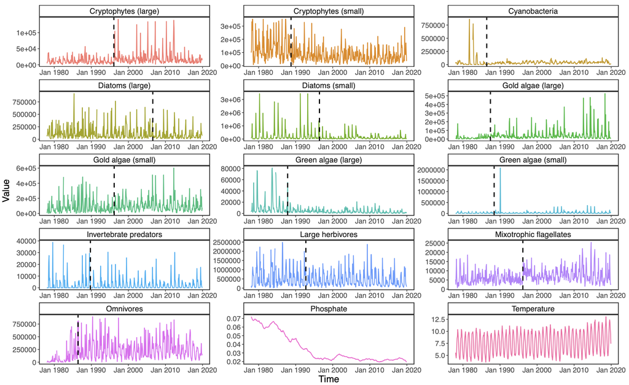

**Figure** 1. This figure was made by Medeiros et al. 2025 (their Fig. S17). Monthly time series for all 13 plankton functional groups (in ind/l), phosphate concentration (in mg/l), and water temperature (in Celsius) from Lake Zurich between January 1978 and December 2019. As explained in the Materials and Methods section in the main text, Medeiros et al. 2025 performed a change-point analysis to determine the location of a potential tipping point for each functional group independently. This potential tipping point is shown for each functional group as a black dashed line and Table S1 gives additional information.

```r
table_s1 <- tribble(
  ~code, ~Group,                     ~`TP month`, ~`SS ratio`, ~Phosphate,
  "Cr2", "Cryptophytes (large)",      "1996-02",    0.940,       0.024,
  "Cr1", "Cryptophytes (small)",      "1988-10",    0.855,       0.043,
  "Cy",  "Cyanobacteria",             "1986-06",    0.991,       0.055,
  "Di2", "Diatoms (large)",           "2006-08",    0.976,       0.023,
  "Di1", "Diatoms (small)",           "1996-06",    0.961,       0.023,
  "Go2", "Gold algae (large)",        "1987-06",    0.961,       0.049,
  "Go1", "Gold algae (small)",        "1996-03",    0.989,       0.024,
  "Gr2", "Green algae (large)",       "1987-11",    0.853,       0.047,
  "Gr1", "Green algae (small)",       "1988-06",    0.996,       0.043,
  "Pr",  "Invertebrate predators",    "1989-10",    0.995,       0.046,
  "He",  "Large herbivores",          "1992-10",    0.980,       0.035,
  "Mi",  "Mixotrophic flagellates",   "1996-03",    0.931,       0.024,
  "Om",  "Omnivores",                 "1986-06",    0.903,       0.055
)
table_s1 %>% select(-code) %>% arrange(`SS ratio`) %>% knitr::kable()
```

**Table** 1. Medeiros et al. 2025, Table S1: change-point analysis for all 13 Lake Zurich functional groups. SS ratio: lower means stronger evidence of a shift (the 3 lowest are their clearest cases).

| Group | TP month | SS ratio | Phosphate |
| --- | --- | --- | --- |
| Green algae (large) | 1987-11 | 0.853 | 0.047 |
| Cryptophytes (small) | 1988-10 | 0.855 | 0.043 |
| Omnivores | 1986-06 | 0.903 | 0.055 |
| Mixotrophic flagellates | 1996-03 | 0.931 | 0.024 |
| Cryptophytes (large) | 1996-02 | 0.940 | 0.024 |
| Diatoms (small) | 1996-06 | 0.961 | 0.023 |
| Gold algae (large) | 1987-06 | 0.961 | 0.049 |
| Diatoms (large) | 2006-08 | 0.976 | 0.023 |
| Large herbivores | 1992-10 | 0.980 | 0.035 |
| Gold algae (small) | 1996-03 | 0.989 | 0.024 |
| Cyanobacteria | 1986-06 | 0.991 | 0.055 |
| Invertebrate predators | 1989-10 | 0.995 | 0.046 |
| Green algae (small) | 1988-06 | 0.996 | 0.043 |

## Results

```r
E <- 3; tau <- 1; Dskipstep <- 16; bandwidth <- 32
L_left <- 200; L_right <- 60
T_z <- nrow(z)

zurich_results <- pmap(table_s1, function(code, Group, `TP month`, `SS ratio`, Phosphate) {
  y <- z[[paste0("scaled_", code)]]
  ym <- as.integer(strsplit(`TP month`, "-")[[1]])
  ref_idx <- zurich_month_index(z, ym[1], ym[2])
  left <- nla_left(y, L = L_left, R = T_z, E = E, tau = tau, Dskipstep = Dskipstep, bandwidth = bandwidth)
  right <- nla_right(y, L = L_right, R = T_z, E = E, tau = tau, Dskipstep = Dskipstep, bandwidth = bandwidth)
  combined <- median(c(left$tau_hat, right$tau_hat), na.rm = TRUE)
  tibble(code = code, Group = Group, `Medeiros date` = `TP month`, `SS ratio` = `SS ratio`,
         `NLA-GP left` = left$tau_hat, `NLA-GP right` = right$tau_hat,
         `NLA-GP combined` = combined,
         `NLA-GP date` = if (is.na(combined)) NA_character_ else format(z$date[round(combined)], "%Y-%m"))
})
```

```r
zurich_summary <- bind_rows(zurich_results) %>% arrange(`SS ratio`)
knitr::kable(zurich_summary %>% select(-code))
```

**Table** 2. NLA-GP detected change points vs. Medeiros et al. 2025 (Table S1), all 13 Lake Zurich functional groups, using the full 1977-2020 series and z-scored (not log-transformed) abundance.

| Group | Medeiros date | SS ratio | NLA-GP left | NLA-GP right | NLA-GP combined | NLA-GP date |
| --- | --- | --- | --- | --- | --- | --- |
| Green algae (large) | 1987-11 | 0.853 | 160 | 144 | 152 | 1989-08 |
| Cryptophytes (small) | 1988-10 | 0.855 | 160 | 176 | 168 | 1990-12 |
| Omnivores | 1986-06 | 0.903 | 64 | NA | 64 | 1982-04 |
| Mixotrophic flagellates | 1996-03 | 0.931 | 96 | 208 | 152 | 1989-08 |
| Cryptophytes (large) | 1996-02 | 0.940 | 96 | NA | 96 | 1984-12 |
| Diatoms (small) | 1996-06 | 0.961 | 80 | 256 | 168 | 1990-12 |
| Gold algae (large) | 1987-06 | 0.961 | NA | 112 | 112 | 1986-04 |
| Diatoms (large) | 2006-08 | 0.976 | 176 | 96 | 136 | 1988-04 |
| Large herbivores | 1992-10 | 0.980 | 144 | NA | 144 | 1988-12 |
| Gold algae (small) | 1996-03 | 0.989 | NA | NA | NA | NA |
| Cyanobacteria | 1986-06 | 0.991 | 80 | 176 | 128 | 1987-08 |
| Invertebrate predators | 1989-10 | 0.995 | 64 | 144 | 104 | 1985-08 |
| Green algae (small) | 1988-06 | 0.996 | NA | 192 | 192 | 1992-12 |

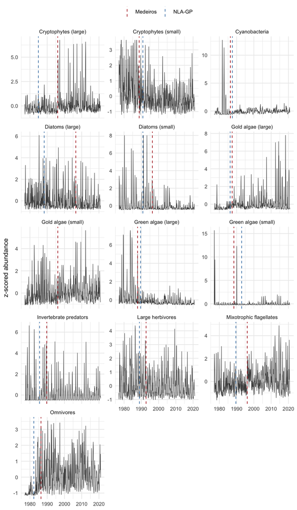

**Figure** 2. Lake Zurich functional groups (z-scored abundance) with Medeiros et al. 2025’s change point (red) and NLA-GP’s combined estimate (blue).

```r
long_ts <- z %>%
  select(date, starts_with("scaled_")) %>%
  pivot_longer(-date, names_to = "code", values_to = "value") %>%
  mutate(code = str_remove(code, "^scaled_")) %>%
  left_join(table_s1 %>% select(code, Group), by = "code")

lines_df <- zurich_summary %>%
  mutate(medeiros_date = as.Date(paste0(`Medeiros date`, "-01")),
         nla_date = if_else(is.na(`NLA-GP date`), as.Date(NA), as.Date(paste0(`NLA-GP date`, "-01"))))

ggplot(long_ts, aes(date, value)) +
  geom_line(linewidth = 0.3, color = "grey30") +
  geom_vline(data = lines_df, aes(xintercept = medeiros_date, color = "Medeiros"), linetype = "dashed") +
  geom_vline(data = lines_df %>% filter(!is.na(nla_date)),
             aes(xintercept = nla_date, color = "NLA-GP"), linetype = "dashed") +
  facet_wrap(~Group, ncol = 3, scales = "free_y") +
  scale_color_manual(values = c(Medeiros = "firebrick", `NLA-GP` = "steelblue"), name = NULL) +
  labs(x = NULL, y = "z-scored abundance") +
  theme_minimal() +
  theme(legend.position = "top")
```

**We conclude:**

- Absolute timing differs from Medeiros et al.’s dates for most groups (Figure 2) – we would *not* claim precise agreement on the calendar date
- Medeiros et al.’s 3 clearest cases (lowest SS ratio: Green algae (large), Cryptophytes (small), Omnivores) are exactly the 3 groups we highlighted in earlier work; Table 2 shows how NLA-GP does on the full set of 13
- NLA-GP’s relative ordering of these 3 clearest groups still tracks Medeiros et al.’s (Omnivores earliest, then Green algae (large), then Cryptophytes (small))

# PDO test

**TipQuestion**

Huang et al. 2024 (Sec. 3.2) applied the original NLA-S-map to the Pacific Decadal Oscillation (PDO) index and detected a shift in its dynamics around 1973, using [monthly PDO data from NOAA](https://github.com/chromian/Nested-Library-Analysis/blob/main/Laboratory/data.csv) (as republished in their own analysis repository). Does NLA-GP find a similar shift, and does it agree with NLA-S-map?

## Data

**To answer this, we:**

- Load the same monthly PDO series, and take a 12-month moving average, restricted to 1875-2000, exactly as Huang et al. 2024 describe
- Fix the **test set to 1875-1919** (the early part) and let the **library (1920-2000) shrink from the right** – i.e. the right check, exactly as they did
- Compare NLA-GP and NLA-S-map’s detected change point to their reported ~1973

```r
pdo <- read.csv(here("data", "raw", "pdo.csv"), skip = 1)
pdo$year <- as.integer(substr(pdo$Date, 1, 4))
pdo$month <- as.integer(substr(pdo$Date, 5, 6))
pdo <- pdo[pdo$year >= 1875 & pdo$year <= 2000, ]
pdo <- pdo[order(pdo$year, pdo$month), ]
pdo$ma <- rollmean(pdo$Value, k = 12, fill = NA, align = "right")
pdo <- pdo[complete.cases(pdo), ]
pdo$idx <- seq_len(nrow(pdo))
```

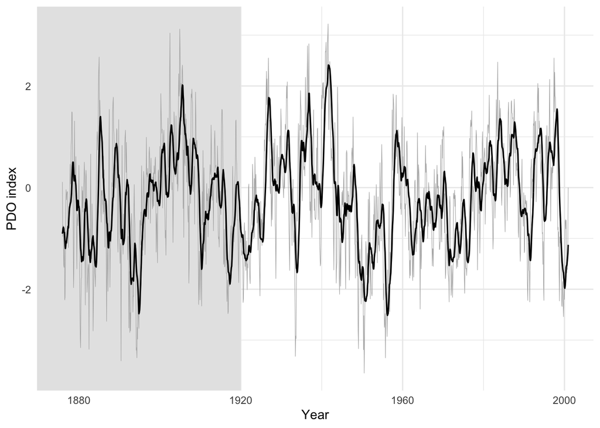

**Figure** 3. Monthly PDO index (grey) and its 12-month moving average (black), 1875-2000. Shaded: the test set (before 1920).

```r
L_pdo <- which.min(abs(pdo$year - 1920))

ggplot(pdo, aes(year + (month - 1) / 12)) +
  geom_rect(xmin = -Inf, xmax = pdo$year[L_pdo], ymin = -Inf, ymax = Inf, fill = "grey90", inherit.aes = FALSE) +
  geom_line(aes(y = Value), color = "grey70", linewidth = 0.2) +
  geom_line(aes(y = ma), linewidth = 0.6) +
  labs(x = "Year", y = "PDO index") +
  theme_minimal()
```

## Results

We use a coarser `Dskipstep` than for Lake Zurich (24 months) since this series is much longer (1501 months); with it, each right check still takes a few minutes.

```r
y_pdo <- pdo$ma
T_pdo <- length(y_pdo)

t0 <- Sys.time()
right_pdo_gp <- nla_right(y_pdo, L = L_pdo, R = T_pdo, E = 3, tau = 1, Dskipstep = 24, bandwidth = 48)
time_pdo_gp <- as.numeric(Sys.time() - t0, units = "secs")

t0 <- Sys.time()
right_pdo_sm <- nla_right_smap(y_pdo, L = L_pdo, R = T_pdo, E = 3, tau = 1, Dskipstep = 24, bandwidth = 48)
time_pdo_sm <- as.numeric(Sys.time() - t0, units = "secs")
```

```r
tibble(Method = c("NLA-GP", "NLA-S-map"),
       `Detected year` = c(
         if (is.na(right_pdo_gp$tau_hat)) NA_character_ else as.character(round(pdo$year[round(right_pdo_gp$tau_hat)])),
         if (is.na(right_pdo_sm$tau_hat)) NA_character_ else as.character(round(pdo$year[round(right_pdo_sm$tau_hat)]))),
       `Huang et al. 2024` = c("~1973", "~1973"),
       `Runtime (s)` = round(c(time_pdo_gp, time_pdo_sm), 1)) %>%
  knitr::kable()
```

**Table** 3. NLA-GP vs. NLA-S-map on the PDO index (right check only, as in Huang et al. 2024), vs. their reported ~1973.

| Method | Detected year | Huang et al. 2024 | Runtime (s) |
| --- | --- | --- | --- |
| NLA-GP | 1982 | ~1973 | 762.0 |
| NLA-S-map | 1940 | ~1973 | 62.9 |

**We conclude:**

- NLA-GP lands closer to Huang et al.’s reported ~1973 than NLA-S-map does here – the opposite of what we found on the synthetic food-chain benchmark, where S-map was far more accurate
- Taken together with the food-chain result, neither method is uniformly better: which one wins seems to depend on the system, not a general property of GP-EDM vs. S-map
- We did not reproduce Huang et al.’s original NLA-S-map result exactly (different smoothing bandwidth/step size, and their own implementation may differ from our reconstruction from S2 Text) – treat this as a rough replication, not a precise one

# Conclusion

- On real Lake Zurich data (full series, all 13 functional groups, z-scored abundance): see Table 2 and Figure 2 for how NLA-GP compares to Medeiros et al. 2025’s change-point analysis
- On the Pacific Decadal Oscillation index (Huang et al. 2024, Sec. 3.2): NLA-GP landed closer to their reported ~1973 shift than our reconstruction of NLA-S-map did (Table 3) – the reverse of the synthetic food-chain result in `1_implement.qmd`
- See `1_implement.qmd` for the algorithm and its validation on synthetic data with a known regime shift